# Resumo

## Objetivo

1. Enteder o alcance e da atividade do MBL no Twitter de modo geral
2. Refinar a hipótese: tweets relacionados à ideologia de gênero foram o principal fator de crescimento do MBL no twitter

## Metodologia

Base de dados:

- Captura e armazenamento de todos os tweets disponíveis publicamente.

Tratamento da base:

- Separação de tweets em somente audiovisual, audiovisual + texto e somente texto
- Tweets sem imagem e com texto sem caracteres serão desconsiderados
- Tratamento das datas

**1. Enteder o alcance e da atividade do MBL no Twitter de modo geral**

```
- Total de tweets
- % de tweets que foram coletados em relação ao total
- Estatísticas descritivas de tweets por semana e geral
- Descrição do uso do twitter ao longo dos anos
- Mediana de retweets, favorites e replies dos tweets ao longo dos anos
- (?) Clusterização de palavras
```

**2. Refinar a hipótese: tweets relacionados à ideologia de gênero foram o principal fator de crescimento do MBL no twitter**

```
- Filtrar tweets de acordo com palavras chave
- Total de tweets | % em relação ao total
- Estatísticas descritivas de tweets por semana e geral
- Comparação com o restante dos tweets
- Mediana de retweets, favorites e replies dos tweets ao longo dos anos
```

## Resultados

Base de dados:

Tratamento da Base:

- Separação de tweets em somente audiovisual, audiovisual + texto e somente texto

[output not shown]

# Importações

```python
import pandas as pd
import sqlite3
import datetime

# DATA ANALYSIS & VIZ TOOLS
from copy import deepcopy

pd.options.display.max_columns = 999

import plotly
import plotly.graph_objs as go
import plotly.offline as offline

offline.init_notebook_mode(connected=True)

%pylab inline
#pylab.rcParams['figure.figsize'] = (12, 12)

colorscale = ['#0095D4', '#7c8282', '#00D9FF', '#b5dde5', '#04b9d3', '#1C5D96'] # visual id
```

## Importação dos dados

### Tweets

```python
db = sqlite3.connect('../scripts/tweets')
```

```python
tweets = pd.read_sql_query('SELECT * FROM tweets_mbl', db)
```

```python
tweets.head(2)
```

|  | tweet_id | account_name | user_id | timestamp | text | links | replies | retweets | favorites | embbed_type | embbed_url | quote | hashtags |
| --- | --- | --- | --- | --- | --- | --- | --- | --- | --- | --- | --- | --- | --- |
| 0 | 348086763811639296 | Mov. Brasil Livre | 1523823530 | 07:35 - 21 de jun de 2013 | Manifestações por um Brasil LIVRE país afora h... | ['https://www.facebook.com/media/set/?set=a.20... | 0 | 4 | 0 |  |  |  | [] |
| 1 | 347760476911964161 | Mov. Brasil Livre | 1523823530 | 09:58 - 20 de jun de 2013 | Brasília também contará com manifestações por ... | ['https://www.facebook.com/events/527324857323... | 0 | 0 | 0 |  |  |  | [] |

```python
tweets['retweets'].max()
```

```
5049
```

```python
tweets.info()
```

```
<class 'pandas.core.frame.DataFrame'>
RangeIndex: 8920 entries, 0 to 8919
Data columns (total 13 columns):
tweet_id        8920 non-null object
account_name    8920 non-null object
user_id         8920 non-null object
timestamp       8920 non-null object
text            8920 non-null object
links           8920 non-null object
replies         8920 non-null int64
retweets        8920 non-null int64
favorites       8920 non-null int64
embbed_type     8920 non-null object
embbed_url      8920 non-null object
quote           8920 non-null object
hashtags        8920 non-null object
dtypes: int64(3), object(10)
memory usage: 906.0+ KB
```

### Interações

```python
interactions = pd.read_sql_query('SELECT * FROM interaction', db)
```

```python
interactions.head(2)
```

|  | tweet_id | interaction_type | username |
| --- | --- | --- | --- |
| 0 | 348086763811639296 | retweet | @naskarmit |
| 1 | 348086763811639296 | retweet | @sejaliber |

```python
interactions.groupby('tweet_id').count().max()
```

```
interaction_type    50
username            50
dtype: int64
```

```python
interactions.info()
```

```
<class 'pandas.core.frame.DataFrame'>
RangeIndex: 347755 entries, 0 to 347754
Data columns (total 3 columns):
tweet_id            347755 non-null object
interaction_type    347755 non-null object
username            347755 non-null object
dtypes: object(3)
memory usage: 8.0+ MB
```

### Texto das imagens

```python
image_text = pd.read_sql_query('SELECT * FROM image_text', db)
```

```python
image_text.head()
```

|  | tweet_id | image_url | image_text |
| --- | --- | --- | --- |
| 0 | 347079507225743360 | https://pbs.twimg.com/media/BNES-RFCEAIwhzV.png | moviment\nBRASILLIVRE\nmedidas para a melhoria... |
| 1 | 348478710418137088 | https://pbs.twimg.com/media/BNYLinKCYAAKMXc.png | ovimento\nBRASILLIVRE\nmedidas para a melhoria... |
| 2 | 347079507225743360 | https://pbs.twimg.com/media/BNES-RFCEAIwhzV.png | moviment\nBRASILLIVRE\nmedidas para a melhoria... |
| 3 | 348478710418137088 | https://pbs.twimg.com/media/BNYLinKCYAAKMXc.png | ovimento\nBRASILLIVRE\nmedidas para a melhoria... |
| 4 | 531095420605571072 | https://pbs.twimg.com/media/B17UeCLIQAAf3B2.jpg | MANIFESTO POR\nUM BRASIL LIVRE\nSOMOS ADULTOS,... |

```python
image_text.describe()
```

|  | tweet_id | image_url | image_text |
| --- | --- | --- | --- |
| count | 2561 | 2561 | 2561 |
| unique | 2559 | 2559 | 2542 |
| top | 348478710418137088 | https://pbs.twimg.com/media/BNYLinKCYAAKMXc.png | LIVE\n |
| freq | 2 | 2 | 2 |

# Tratamento

## Tweets duplicados

```python
print('Número de tweets duplicados: ', len(tweets) - len(tweets.drop_duplicates('tweet_id')))
```

```
Número de tweets duplicados:  10
```

```python
tweets = tweets.drop_duplicates('tweet_id')
```

### Limpa texto das images

```python
def clean_text(text):
    """Cleans raw text so that it can be written into a csv file without causing any errors."""
    text = ''.join(list(map(lambda x: x if isinstance(x, str) else x.text, text)))
    temp = text
    temp = temp.replace("\n", " ")
    temp = temp.replace("\r", " ")
    temp = temp.replace(",", " ")
    temp.strip()
    return temp

image_text['image_text'] = image_text['image_text'].apply(clean_text)
```

## Divisão por audiovisual e texto

```python
tweets['links_len'] = tweets['links'].apply(len) - 2
tweets['image_len'] = tweets['embbed_url'].apply(len)
tweets['text_len'] = tweets['text'].apply(len)
```

```python
print('tweets:', len(tweets))
print('tweets que contém imagem:', len(tweets[tweets['image_len'] > 0]))
print('tweets que contém texto:', len(tweets[tweets['text_len'] > 0]))
print('tweets que contém links externos:', len(tweets[tweets['links_len'] > 0]))
print('tweets que contém somente texto:', len(tweets[(tweets['links_len'] == 0) &
                                                     (tweets['text_len'] > 0) &
                                                     (tweets['image_len'] == 0)]))
print('tweets que contém somente links:', len(tweets[(tweets['links_len'] > 0) &
                                                     (tweets['text_len'] == 0) &
                                                     (tweets['image_len'] == 0)]))
print('tweets que contém somente images:', len(tweets[(tweets['links_len'] == 0) &
                                                     (tweets['text_len'] == 0) &
                                                     (tweets['image_len'] > 0)]))
print('tweets que contém texto+imagens:', len(tweets[(tweets['links_len'] == 0) &
                                                     (tweets['text_len'] > 0) &
                                                     (tweets['image_len'] > 0)]))
print('tweets que contém links+imagens:', len(tweets[(tweets['links_len'] > 0) &
                                                     (tweets['text_len'] == 0) &
                                                     (tweets['image_len'] > 0)]))
print('tweets que contém texto+links:', len(tweets[(tweets['links_len'] > 0) &
                                                     (tweets['text_len'] > 0) &
                                                     (tweets['image_len'] == 0)]))
print('tweets que contém links+imagens+texto:', len(tweets[(tweets['links_len'] > 0) &
                                                     (tweets['text_len'] > 0) &
                                                     (tweets['image_len'] > 0)]))
print('tweets que contém vazios:', len(tweets[(tweets['links_len'] == 0) &
                                                     (tweets['text_len'] == 0) &
                                                     (tweets['image_len'] == 0)]))
```

```
tweets: 8910
tweets que contém imagem: 2718
tweets que contém texto: 8638
tweets que contém links externos: 4399
tweets que contém somente texto: 2093
tweets que contém somente links: 47
tweets que contém somente images: 94
tweets que contém texto+imagens: 2249
tweets que contém links+imagens: 56
tweets que contém texto+links: 3977
tweets que contém links+imagens+texto: 319
tweets que contém vazios: 75
```

## Treat dates

```python
month_converter = {
    'jan': 'jan',
    'fev': 'feb',
    'mar': 'mar',
    'abr': 'apr',
    'mai': 'may',
    'jun': 'jun',
    'jul': 'jul',
    'ago': 'aug',
    'set': 'sep',
    'out': 'oct',
    'nov': 'nov',
    'dez': 'dec',
}
```

```python
def translate_month(a):
    month = a[-11:-8]
    return a.replace(month, month_converter[month])
```

```python
tweets['timestamp'] = tweets['timestamp'].apply(lambda a : datetime.datetime.strptime(translate_month(a), '%H:%M - %d de %b de %Y'))
```

```python
tweets.set_index('timestamp', inplace=True)
```

# Alcance da atividade do MBL no Twitter

Como as atividades no twitter só começam em Outubro de 2014, o período anterior será descartado.

Mais precisamente da data '2014-11-14 06:52:00'

- Total de tweets
- Estatísticas descritivas de tweets por semana e geral
- Descrição do uso do twitter ao longo dos anos
- Mediana de retweets, favorites e replies dos tweets ao longo dos anos
- (?) Clusterização de palavras

## Filtra data

```python
tweets = tweets['01-10-2014':]
```

## Total de Tweets

```python
def count_group(df, groups=['D', 'W', 'M'], agg='count', select=['tweet_id']):
    count = {}
    for freq in groups:
        count[freq] = df.groupby(pd.Grouper(freq=freq)).agg(agg)[select]

    return count
```

```python
tweets_count = count_group(tweets, groups=['D', 'W', 'M', 'Y'])
```

### Agregado

```python
print('Total de tweets: ', len(tweets))
```

```
Total de tweets:  8900
```

### Por Ano

```python
tweets_count['Y']
```

| timestamp | tweet_id |
| --- | --- |
| 2014-12-31 | 125 |
| 2015-12-31 | 2526 |
| 2016-12-31 | 1923 |
| 2017-12-31 | 2413 |
| 2018-12-31 | 1913 |

```python
data = [go.Bar(x=tweets_count['Y'].index - 1,
             y=tweets_count['Y']['tweet_id'])]

layout = go.Layout(title='Number of tweets per year')
fig = dict(layout=layout, data=data)
offline.iplot(fig)
```

[interactive chart not shown]

### Por Mês

```python
data = [go.Bar(x=tweets_count['M'].index ,
             y=tweets_count['M']['tweet_id'])]

layout = go.Layout(title='Number of tweets per month')
fig = dict(layout=layout, data=data)
offline.iplot(fig)
```

[interactive chart not shown]

### Por Semana

```python
data = [go.Bar(x=tweets_count['W'].index ,
             y=tweets_count['W']['tweet_id'])]

layout = go.Layout(title='Number of tweets per week')
fig = dict(layout=layout, data=data)
offline.iplot(fig)
```

[interactive chart not shown]

### Distribuição de tweets por semana

```python
tweets_count['W']['tweet_id'].describe()
```

```
count    196.000000
mean      45.408163
std       23.659914
min        0.000000
25%       28.750000
50%       44.500000
75%       61.000000
max      139.000000
Name: tweet_id, dtype: float64
```

```python
data = [go.Histogram(
             x=tweets_count['W']['tweet_id'],
            autobinx=True)]

layout = go.Layout(title='Number of tweets per week')
fig = dict(layout=layout, data=data)
offline.iplot(fig)
```

[interactive chart not shown]

### Média móvel de um mês de tweets por semana

```python
data = [go.Scatter(
            x=tweets_count['W'].index,
            y=tweets_count['W']['tweet_id'],
            mode='markers',
            name='Number of Tweets')]

data.append(go.Scatter(
                x=tweets_count['W'].index,
                y=tweets_count['W']['tweet_id'].rolling(4, closed='right', min_periods=1).mean(),
                name='Rolling Month Average'))

data.append(go.Scatter(
                x=tweets_count['W'].index,
                y=tweets_count['W']['tweet_id'].rolling(4, closed='right', min_periods=1).median(),
                name='Rolling Month Median'))

layout = go.Layout(title='Number of tweets per week')
fig = dict(layout=layout, data=data)
offline.iplot(fig)
```

[interactive chart not shown]

```python
from statsmodels.tsa.seasonal import seasonal_decompose

result = seasonal_decompose(tweets_count['W']['tweet_id'].rolling(4, closed='right', min_periods=1).mean(),
                            model='additive')

data = []

data.append(go.Scatter(
                x=tweets_count['W'].index,
                y=tweets_count['W']['tweet_id'].rolling(4, closed='right', min_periods=1).mean(),
                name='Rolling Month Median'))

data.append(go.Scatter(
                x=result.trend.index,
                y=result.trend,
                name='Trend'))

data.append(go.Scatter(
                x=result.seasonal.index,
                y=result.seasonal,
                name='Seasonal'))

data.append(go.Scatter(
                x=result.resid.index,
                y=result.resid,
                name='Residual'))

layout = go.Layout(title='Number of tweets per week - Decomposition')
fig = dict(layout=layout, data=data)
offline.iplot(fig)
```

[interactive chart not shown]

## Impacto - Retweets, Favorites e Replies

```python
tweets_sum = {'retweets': count_group(tweets, groups=['D', 'W', 'M', 'Y'], select=['retweets'], agg='sum'),
                'favorites': count_group(tweets, groups=['D', 'W', 'M', 'Y'], select=['favorites'], agg='sum'),
                'replies': count_group(tweets, groups=['D', 'W', 'M', 'Y'], select=['replies'], agg='sum'),
               }
tweets_median = {'retweets': count_group(tweets, groups=['D', 'W', 'M', 'Y'], select=['retweets'], agg='median'),
                'favorites': count_group(tweets, groups=['D', 'W', 'M', 'Y'], select=['favorites'], agg='median'),
                'replies': count_group(tweets, groups=['D', 'W', 'M', 'Y'], select=['replies'], agg='median'),
               }
```

### Agregado

```python
print('Total de retweets: ', tweets['retweets'].sum())
print('Total de favorites: ', tweets['favorites'].sum())
print('Total de replies: ', tweets['replies'].sum())
```

```
Total de retweets:  1022799
Total de favorites:  2158227
Total de replies:  179702
```

### Por Ano

```python
data = []

for interaction in tweets_sum:
    data.append(go.Bar(
                    x=tweets_sum[interaction]['Y'].index - 1,
                    y=tweets_sum[interaction]['Y'][interaction],
                    name=interaction))

layout = go.Layout(title='Number of interactions per year')
fig = dict(layout=layout, data=data)
offline.iplot(fig)
```

[interactive chart not shown]

```python
data = []

for interaction in tweets_median:
    data.append(go.Bar(
                    x=tweets_median[interaction]['Y'].index - 1,
                    y=tweets_median[interaction]['Y'][interaction],
                    name=interaction))

layout = go.Layout(title='Median of interactions per tweet per year')
fig = dict(layout=layout, data=data)
offline.iplot(fig)
```

[interactive chart not shown]

### Por Mês

```python
data = []

for interaction in tweets_sum:
    data.append(go.Scatter(
                    x=tweets_sum[interaction]['M'].index,
                    y=tweets_sum[interaction]['M'][interaction],
                    name=interaction))

layout = go.Layout(title='Number of interactions per month')
fig = dict(layout=layout, data=data)
offline.iplot(fig)
```

[interactive chart not shown]

```python
data = []

for interaction in tweets_median:
    data.append(go.Scatter(
                    x=tweets_median[interaction]['M'].index,
                    y=tweets_median[interaction]['M'][interaction],
                    name=interaction))

layout = go.Layout(title='Median of interactions per tweet per month')
fig = dict(layout=layout, data=data)
offline.iplot(fig)
```

[interactive chart not shown]

### Por Semana

```python
data = []

for interaction in tweets_sum:
    data.append(go.Scatter(
                    x=tweets_sum[interaction]['W'].index,
                    y=tweets_sum[interaction]['W'][interaction],
                    name=interaction))

layout = go.Layout(title='Median of interactions per week')
fig = dict(layout=layout, data=data)
offline.iplot(fig)
```

[interactive chart not shown]

```python
data = []

for interaction in tweets_median:
    data.append(go.Scatter(
                    x=tweets_median[interaction]['W'].index,
                    y=tweets_median[interaction]['W'][interaction],
                    name=interaction))

layout = go.Layout(title='Median of interactions per tweet per week')
fig = dict(layout=layout, data=data)
offline.iplot(fig)
```

[interactive chart not shown]

### Distribuição de tweets por semana

```python
tweets_sum['replies']['W']['replies'].describe(), tweets_sum['retweets']['W']['retweets'].describe(), tweets_sum['favorites']['W']['favorites'].describe()
```

```
(count     196.000000
 mean      916.846939
 std      1015.828164
 min         0.000000
 25%       160.250000
 50%       587.500000
 75%      1428.000000
 max      7079.000000
 Name: replies, dtype: float64, count      196.000000
 mean      5218.362245
 std       5199.980600
 min          0.000000
 25%       1424.500000
 50%       4215.000000
 75%       7756.000000
 max      42919.000000
 Name: retweets, dtype: float64, count       196.000000
 mean      11011.362245
 std       14298.644614
 min           0.000000
 25%        1408.250000
 50%        6507.500000
 75%       16082.750000
 max      135505.000000
 Name: favorites, dtype: float64)
```

```python
data = []

for interaction in tweets_sum:
    data.append(go.Histogram(
                    x=tweets_sum[interaction]['W'][interaction],
                    name=interaction,
                    opacity=0.9))

layout = go.Layout(title='Median of interactions per week',
                  xaxis=dict(range=[0, 10000]),)
fig = dict(layout=layout, data=data)
offline.iplot(fig)
```

[interactive chart not shown]

### Média móvel de um mês de tweets por semana

```python
data = []

for i, interaction in enumerate(tweets_sum):
    data.append(go.Scatter(
                    x=tweets_sum[interaction]['W'].index,
                    y=tweets_sum[interaction]['W'][interaction],
                    name=interaction,
                    mode='markers',
                    marker=dict(color=colorscale[i])))

    data.append(go.Scatter(
                    x=tweets_sum[interaction]['W'].index,
                    y=tweets_sum[interaction]['W'][interaction].rolling(4, closed='right', min_periods=1).median(),
                    name=interaction + ' Rolling Month Median',
                    marker=dict(color=colorscale[i])))

layout = go.Layout(title='Number of interactions per week')
fig = dict(layout=layout, data=data)
offline.iplot(fig)
```

[interactive chart not shown]

## Público

```python
interactions.head()
```

|  | tweet_id | interaction_type | username |
| --- | --- | --- | --- |
| 0 | 348086763811639296 | retweet | @naskarmit |
| 1 | 348086763811639296 | retweet | @sejaliber |
| 2 | 348086763811639296 | retweet | @FabioOstermann |
| 3 | 347760043241906176 | retweet | @FabioOstermann |
| 4 | 347202762523684864 | retweet | @LucasGelasio |

### Top Contas

```python
interactions.groupby(['username']).count()['tweet_id'].sort_values(ascending=False)
```

```
username
@vidal31415         3182
@0686966667ff496    2575
@ricanani           1506
@maracaja05         1401
@marcus_medeiros    1324
@ArobertoSa         1211
@csanjel1           1121
@EliORiordan        1071
@luciaazevedo       1032
@thyagofrassetto     962
@alexlimareal        935
@Renato_SVP          836
@rosangela_bolze     830
@Bobmeirelles        792
@LuisCarlosBast4     683
@duduacgsfc          668
@paulormt            637
@Enidepaula          634
@Ary_AntiPT          568
@benevides_cris      567
@___DENISE___EU_     552
@zkfalcao            549
@Liberty_Brasil      530
@madrynha2012        523
@FAL9CCON            511
@BRsempt             507
@garcez_ian          506
@BattistaTania       503
@black_Flag17        493
@ricsobreira         493
                    ...
@jrwatzel              1
@RihFla                1
@RighteousOrMad        1
@RightPumba            1
@RichofMonaco          1
@juanmoreiira          1
@juanitosantosz        1
@Richard230203         1
```

[output cut: 8 more lines]

```
@RickCellos            1
@RiderCastro           1
@RickEstanieski        1
@ju_sincera            1
@ju_s2_roo             1
@Rick_OPSR             1
@Rickoficial4          1
@Rickpqdt              1
@Riclsa                1
@ju_petito             1
@RicoPCoelho           1
@ju_mozza              1
@ju_bbueno             1
@arthurr_mendes        1
Name: tweet_id, Length: 54377, dtype: int64
```

### Fidelidade

Número de usuários com mais de uma interação ao longo dos anos

```python
interactions = interactions.merge(tweets.reset_index(), on='tweet_id').sort_values(by=['timestamp']).reset_index()
```

```python
first_inter = interactions[['index', 'username', 'timestamp', 'tweet_id']].groupby('username').first()
repeated_inter = interactions[~(interactions['index'].isin(first_inter['index']))]
```

```python
first_inter = first_inter.set_index('timestamp')
repeated_inter = repeated_inter.set_index('timestamp')
```

```python
len(repeated_inter.reset_index()['username'].unique()) / len(repeated_inter)
```

```
0.09138329571721772
```

```python
len(repeated_inter) + len(first_inter) == len(interactions)
```

```
True
```

```python
fidelidade_count = {'novo': count_group(first_inter, agg='count', groups=['W', 'M', 'Y']),
                    'fiel': count_group(repeated_inter, agg='count', groups=['W', 'M', 'Y']),}
```

```python
data = []

for interaction in fidelidade_count:
    data.append(go.Bar(
                    x=fidelidade_count[interaction]['Y'].index,
                    y=fidelidade_count[interaction]['Y']['tweet_id'],
                    name=interaction))

layout = go.Layout(title='Fidelidade da interação por ano', barmode='stack')
fig = dict(layout=layout, data=data)
offline.iplot(fig)
```

[interactive chart not shown]

```python
data = []

for interaction in fidelidade_count:
    data.append(go.Bar(
                    x=fidelidade_count[interaction]['M'].index,
                    y=fidelidade_count[interaction]['M']['tweet_id'],
                    name=interaction))

layout = go.Layout(title='Fidelidade da interação por mês', barmode='stack')
fig = dict(layout=layout, data=data)
offline.iplot(fig)
```

[interactive chart not shown]

```python
data = []

for interaction in fidelidade_count:
    data.append(go.Scatter(
                    x=fidelidade_count[interaction]['W'].index,
                    y=fidelidade_count[interaction]['W']['tweet_id'],
                    name=interaction))

layout = go.Layout(title='Fidelidade da interação por semana')
fig = dict(layout=layout, data=data)
offline.iplot(fig)
```

[interactive chart not shown]

```python
data = []

total = fidelidade_count['novo']['M'].merge(fidelidade_count['fiel']['M'], right_index=True, left_index=True, how='outer',
                                  suffixes=('_novo', '_fiel')).fillna(0)

for interaction in fidelidade_count:
    if interaction == 'novo':
        data.append(go.Bar(
                    x=total.index,
                    y=total['tweet_id_'+interaction] / total.sum(1),
                    name=interaction))

layout = go.Layout(title='Porcentagem de novos usuários interagindo por mês',
                  yaxis=dict(range=[0,1]))
fig = dict(layout=layout, data=data)
offline.iplot(fig)
```

[interactive chart not shown]

```python
data = []

total = fidelidade_count['novo']['W'].merge(fidelidade_count['fiel']['W'], right_index=True, left_index=True, how='outer',
                                  suffixes=('_novo', '_fiel')).fillna(0)

for interaction in fidelidade_count:
    if interaction == 'novo':
        data.append(go.Scatter(
                    x=total.index,
                    y=total['tweet_id_'+interaction] / total.sum(1),
                    name=interaction))

layout = go.Layout(title='Porcentagem de novos usuários interagindo por semana',
                  yaxis=dict(range=[0,1]))
fig = dict(layout=layout, data=data)
offline.iplot(fig)
```

[interactive chart not shown]

# Indentificação de Temas

```python
from gensim.test.utils import common_texts,common_corpus
from gensim.corpora.dictionary import Dictionary
from gensim.models import LdaModel
import re
from gensim.utils import tokenize
import nltk
import gensim
```

```python
## Transform data
```

```python
tweet_text = tweets[['tweet_id', 'text', 'quote']].merge(image_text[['tweet_id', 'image_text']], on='tweet_id', how='outer')
tweet_text = tweet_text[['text', 'quote', 'image_text']].fillna('')
tweet_text = tweet_text.apply(lambda x: x['text'] + x['quote'] + x['image_text'], axis=1)
re.sub('http\S+', '', tweet_text[0])
tweet_text = tweet_text.apply(lambda x: re.sub(r'http\S+', '', x, flags=re.MULTILINE))
tweet_text = [list(tokenize(text)) for text in list(tweet_text)]
```

```python
stopwords = nltk.corpus.stopwords.words('portuguese')
stopwords = stopwords + ['mbl', 'twitter', 'youtube', 'pic', 'é', 'h',
                         'facebook', 'r', 'ep', 's', 'n', 'lo', 'faz', 'hora', 'pra', 'p','f']

tweet_text = [[word.lower() for word in document if word.lower() not in stopwords]
              for document in tweet_text]
```

```python
## Train Model
```

```python
# Create a corpus from a list of texts
common_dictionary = Dictionary(tweet_text)
corpus = [common_dictionary.doc2bow(text) for text in tweet_text]
tfidf = gensim.models.TfidfModel(corpus)
corpus_tfidf = tfidf[corpus]
# Train the model on the corpus.
lda = gensim.models.LsiModel(corpus_tfidf, num_topics=10, id2word=common_dictionary)
```

```python
lda.show_topics()
```

```
[(0,
  '0.311*"vivo" + 0.257*"via" + 0.250*"brasil" + 0.239*"news" + 0.215*"livre" + 0.202*"movimento" + 0.187*"lula" + 0.163*"dilma" + 0.160*"pt" + 0.139*"impeachment"'),
 (1,
  '-0.777*"vivo" + -0.417*"news" + 0.166*"brasil" + 0.160*"livre" + 0.150*"movimento" + 0.093*"pt" + 0.089*"dilma" + 0.089*"impeachment" + 0.085*"dia" + 0.082*"curta"'),
 (2,
  '-0.563*"via" + -0.325*"kim" + 0.293*"livre" + -0.293*"kataguiri" + 0.264*"movimento" + 0.264*"vivo" + 0.247*"brasil" + 0.164*"curta" + -0.110*"lula" + 0.106*"marcha"'),
 (3,
  '0.319*"livre" + 0.305*"kim" + 0.282*"kataguiri" + 0.279*"via" + 0.270*"movimento" + 0.252*"brasil" + -0.252*"lula" + -0.165*"dilma" + 0.158*"curta" + -0.141*"contra"'),
 (4,
  '-0.648*"marcha" + -0.441*"liberdade" + -0.248*"dia" + 0.223*"livre" + -0.219*"brasília" + 0.202*"brasil" + 0.192*"movimento" + -0.135*"todos" + 0.098*"curta" + -0.077*"chegando"'),
 (5,
  '0.432*"impeachment" + 0.373*"dilma" + -0.345*"lula" + -0.240*"marcha" + 0.177*"kim" + 0.172*"kataguiri" + -0.168*"liberdade" + -0.165*"jato" + -0.164*"lava" + -0.160*"news"'),
 (6,
  '-0.299*"jato" + -0.298*"lava" + 0.274*"pt" + -0.267*"lula" + 0.250*"reforma" + 0.233*"previdência" + -0.192*"kim" + -0.182*"kataguiri" + 0.178*"ajude" + -0.141*"impeachment"'),
 (7,
  '0.404*"news" + -0.341*"kim" + -0.328*"kataguiri" + 0.320*"via" + 0.230*"dilma" + 0.228*"impeachment" + -0.224*"vivo" + -0.182*"pt" + 0.180*"dia" + 0.145*"brasília"'),
 (8,
  '0.592*"dia" + -0.448*"dilma" + -0.258*"marcha" + 0.198*"bom" + -0.162*"liberdade" + 0.128*"vai" + -0.125*"curta" + 0.113*"todos" + 0.112*"ruas" + -0.104*"rousseff"'),
 (9,
  '0.339*"paulo" + 0.287*"holiday" + -0.268*"lula" + 0.243*"fernando" + -0.238*"dilma" + -0.214*"pt" + 0.207*"lava" + 0.207*"jato" + 0.176*"contra" + -0.146*"preso"')]
```

```python
from collections import OrderedDict
import seaborn as sns
data = {i: OrderedDict(lda.show_topic(i,10)) for i in range(10)}
```

```python
df = pd.DataFrame(data)
df = df.fillna(0).T
```

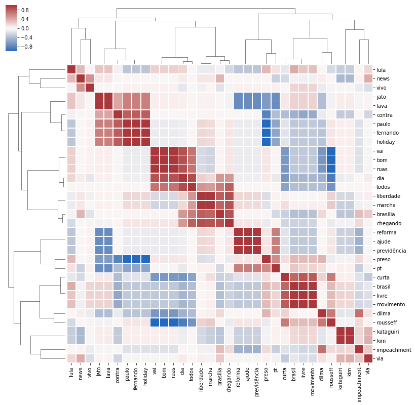

```python
sns.clustermap(df.corr(), center=0, cmap="vlag", metric='cosine',
               linewidths=.75, figsize=(13, 13))
```

# Tweets por Tema

## Importando keywords dos temas

```python
import yaml
```

```python
keywords = yaml.load(open('keywords.yaml', 'r'))
```

```python
keywords.keys()
```

```
dict_keys(['corrupcao', 'economia', 'seguranca-publica', 'ideologia-genero'])
```

## Selecionando Tweets por keyword

```python
tweets_text = tweets[['tweet_id', 'text', 'quote', 'hashtags']].merge(image_text[['tweet_id', 'image_text']],
                                                                      on='tweet_id', how='left', right_index=True)
tweets_text = tweets_text.set_index('tweet_id')
```

```python
tweets_text.head(2)
```

| tweet_id | text | quote | hashtags | image_text |
| --- | --- | --- | --- | --- |
| 533271260785311744 | Nosso press release protocolado na Folha. Dess... |  | [] | NaN |
| 532934479128821761 | MAVs agindo para deslegitimar o movimento. Art... |  | [] | NaN |

```python
from collections import defaultdict

def search_keywords(df, keywords):

    result = defaultdict(lambda: pd.DataFrame())
    for theme, keys in keywords.items():
        for key in keys:
            if '(...)' in key:
                first, second = [a.strip() for a in key.split('(...)')]
                key = '({}).*({})'.format(first, second)

            result[theme][key] = (df['text'].str.contains(key, regex=True, case=False) |
                                     (df['image_text'].str.contains(key, regex=True, case=False)) |
                                     (df['image_text'].str.contains(key, regex=True, case=False)))

    return result
```

### Sem tratamento

```python
search_result = search_keywords(tweets_text, keywords)
```

#### Quantidade de Tweets por Tema

```python
no_theme = []
for theme in search_result.keys():
    no_theme.extend(list(search_result[theme][search_result[theme].sum(1) == 0].index))

no_theme = pd.Series(no_theme).value_counts()
no_theme = list(no_theme[no_theme == len(search_result.keys())].index)
```

```python
data = [go.Bar( x=[theme for theme in search_result.keys()] + ['Sem tema'],
                y=[search_result[theme].sum(1).sum() for theme in search_result.keys()] + [len(no_theme)],
                name=theme,
                opacity=0.9)]

layout = go.Layout(title='Number of tweets by theme',)
fig = dict(layout=layout, data=data)
offline.iplot(fig)
```

[interactive chart not shown]

#### Quantidade de Tweets por Tema por Mês

```python
def count_date(search_result, tweets, theme, freq):
    return (search_result[theme].merge(tweets[['tweet_id']], left_index=True, right_on='tweet_id')
            .groupby(pd.Grouper(freq=freq)).agg('sum').sum(1))
```

```python
data = []

for theme in search_result.keys():
    print(theme)
    res = count_date(search_result, tweets, theme, 'M')
    data.append(go.Scatter(
                    x=res.index,
                    y=res,
                    name=theme))

layout = go.Layout(title='Number of tweets by theme per month')
fig = dict(layout=layout, data=data)
offline.iplot(fig)
```

```
corrupcao
economia
seguranca-publica
ideologia-genero
```

[interactive chart not shown]

#### Interações por Tema

```python
def theme_interaction(interactions, search_result, theme):

    return (interactions[
                interactions['tweet_id']
                    .isin(search_result[theme][search_result[theme].sum(1) > 0].index)]
            )
```

```python
data = [go.Bar( x=[theme for theme in search_result.keys()],
                y=[theme_interaction(tweets, search_result, theme)['retweets'].sum() for theme in search_result.keys()],
                name=theme,
                opacity=0.9)]

layout = go.Layout(title='Number of retweets per theme',)
fig = dict(layout=layout, data=data)
offline.iplot(fig)
```

[interactive chart not shown]

```python
data = [go.Bar( x=[theme for theme in search_result.keys()],
                y=[theme_interaction(interactions, search_result, theme)['retweets'].sum()/search_result[theme].sum(1).sum()
                   for theme in search_result.keys()],
                name=theme,
                opacity=0.9)]

layout = go.Layout(title='Mean Number of retweets per theme',)
fig = dict(layout=layout, data=data)
offline.iplot(fig)
```

[interactive chart not shown]

#### Interações por tema por mês

```python
def count_interaction(tweets, search_result, theme, freq, interaction_type):
    return (theme_interaction(tweets, search_result, theme)
            .groupby(pd.Grouper(freq=freq)).agg('sum'))[interaction_type]
```

```python
data = []

for theme in search_result.keys():
    res = count_interaction(tweets, search_result, theme, 'M', 'retweets')
    data.append(go.Scatter(
                    x=res.index,
                    y=res,
                    name=theme))

layout = go.Layout(title='Number of interactions by theme per month')
fig = dict(layout=layout, data=data)
offline.iplot(fig)
```

[interactive chart not shown]

```python
data = []

for theme in search_result.keys():
    res = count_interaction(tweets, search_result, theme, 'M', 'retweets')
    data.append(go.Scatter(
                    x=res.index,
                    y=res / count_date(search_result, tweets, theme, 'M'),
                    name=theme))

layout = go.Layout(title='Mean number of retweets by theme per month')
fig = dict(layout=layout, data=data)
offline.iplot(fig)
```

[interactive chart not shown]

```python
search_result['seguranca-publica'].merge(tweets, left_index=True, right_on='tweet_id')['04/2016':'05/2016'].sort_values(by='retweets', ascending=False)
```

| timestamp | aprisionar | encarcerar | prender | preso | prisão | prisões | arma | armamento | porte (…) arma | pena | penal | punir | condução coercitiva | presídios | polícia | policial | tweet_id | account_name | user_id | text | links | replies | retweets | favorites | embbed_type | embbed_url | quote | hashtags | links_len | … |
| --- | --- | --- | --- | --- | --- | --- | --- | --- | --- | --- | --- | --- | --- | --- | --- | --- | --- | --- | --- | --- | --- | --- | --- | --- | --- | --- | --- | --- | --- | --- |
| 2016-05-11 13:09:00 | False | False | False | False | False | False | False | False | False | False | False | False | False | False | True | False | 730490142209781764 | Mov. Brasil Livre | 1523823530 | Maria do Rosário colocou um banner "contra o g... | [] | 264 | 1703 | 1934 | image | https://pbs.twimg.com/media/CiM46Z_WkAAbYHI.jpg |  | [] | 0 | … |
| 2016-05-02 09:20:00 | False | False | False | False | False | False | False | False | False | False | False | False | False | False | False | False | 727170899342970880 | Mov. Brasil Livre | 1523823530 |  | [] | 28 | 1306 | 1328 | image | https://pbs.twimg.com/media/ChduFBbWYAAgEKT.jpg |  | [] | 0 | … |
| 2016-04-20 14:18:00 | False | False | False | False | False | False | False | False | False | False | False | False | False | False | False | False | 722897350927069184 | Mov. Brasil Livre | 1523823530 | Um absurdo o limite de franquia! Mais liberdad... | [] | 42 | 763 | 472 | image | https://pbs.twimg.com/media/Cgg_TyEWEAA-AIq.jpg |  | [] | 0 | … |
| 2016-04-20 08:57:00 | False | False | False | False | False | False | False | False | False | False | False | False | False | False | False | False | 722816481021415426 | Mov. Brasil Livre | 1523823530 | Além da Dilma estamos prestes a ver também a ... | [] | 59 | 744 | 858 | image | https://pbs.twimg.com/media/Cgf1wiNWEAALvjG.jpg |  | [] | 0 | … |
| 2016-05-03 16:15:00 | False | False | False | False | False | False | False | False | False | False | False | False | False | False | False | False | 727637862108286976 | Mov. Brasil Livre | 1523823530 | Eu já sabia.pic.twitter.com/CR4cycyMGl | [] | 27 | 703 | 486 | image | https://pbs.twimg.com/media/ChkWx0fW0AAQetr.jpg |  | [] | 0 | … |
| 2016-04-17 19:29:00 | False | False | False | False | False | False | False | False | False | False | False | False | False | False | False | False | 721888370562043904 | Mov. Brasil Livre | 1523823530 | E A CARRETA FURACÃO?pic.twitter.com/9140ySd51F | [] | 31 | 697 | 632 |  |  |  | [] | 0 | … |
| 2016-04-19 15:48:00 | False | False | False | False | False | False | False | False | False | False | False | False | False | False | False | False | 722557540802936832 | Mov. Brasil Livre | 1523823530 | O MBL vai entrar nessa luta.pic.twitter.com/E9... | [] | 48 | 639 | 687 | image | https://pbs.twimg.com/media/CgcKQK0WIAAuAGb.jpg |  | [] | 0 | … |
| 2016-04-11 17:01:00 | False | False | False | False | False | False | False | False | False | False | False | False | False | False | False | False | 719676841653628929 | Mov. Brasil Livre | 1523823530 | LISTA DA VERGONHA!pic.twitter.com/kBRwzuPaeE | [] | 38 | 612 | 440 | image | https://pbs.twimg.com/media/CfzORe4WQAAliW9.jpg |  | [] | 0 | … |
| 2016-04-09 16:02:00 | False | False | False | False | False | False | False | False | False | False | False | False | False | False | False | False | 718937272121499648 | Mov. Brasil Livre | 1523823530 | Datafolha é aquela pesquisa pautada pelo Lula.... | [] | 84 | 594 | 554 |  |  |  | [] | 0 | … |
| 2016-04-04 13:44:00 | False | False | False | False | False | False | False | False | False | False | False | False | False | False | False | False | 717090513627848713 | Mov. Brasil Livre | 1523823530 | O impeachment já tem mais de 300 votos! Vamos ... | [] | 24 | 540 | 629 | image | https://pbs.twimg.com/media/CfOeBXfW4AElAB2.jpg |  | [] | 0 | … |
| 2016-04-28 07:47:00 | False | False | False | False | False | False | False | False | False | False | False | False | False | False | False | False | 725697883081691137 | Mov. Brasil Livre | 1523823530 | As definições da esquerda.pic.twitter.com/vfkt... | [] | 25 | 520 | 559 | image | https://pbs.twimg.com/media/ChIyYKXXEAAbRsd.jpg |  | [] | 0 | … |
| 2016-04-29 09:05:00 | False | False | False | False | False | False | False | False | False | False | False | False | False | False | False | False | 726079988500455424 | Mov. Brasil Livre | 1523823530 | Novo programa do PT. Garantindo Foro e atrasan... | [] | 28 | 516 | 519 | image | https://pbs.twimg.com/media/ChON5qrWYAAH8RG.jpg |  | [] | 0 | … |
| 2016-05-28 08:00:00 | False | False | False | False | False | False | False | False | False | False | False | False | False | False | False | False | 736572870541869056 | Mov. Brasil Livre | 1523823530 | Ué @gleisi ???pic.twitter.com/xxx68spuur | [] | 59 | 515 | 717 | image | https://pbs.twimg.com/media/CjjVH0iWkAEEwk4.jpg |  | [] | 0 | … |
| 2016-05-17 13:11:00 | False | False | False | False | False | False | False | False | False | False | False | False | False | False | False | False | 732664778766876675 | Mov. Brasil Livre | 1523823530 | Privatiza os Correios!pic.twitter.com/d1n1VWWr6C | [] | 39 | 512 | 361 | image | https://pbs.twimg.com/media/CiryuyAW0AINKkO.jpg |  | [] | 0 | … |
| 2016-05-23 14:41:00 | False | False | False | False | False | False | False | False | False | False | False | False | False | False | False | False | 734861937037692928 | Mov. Brasil Livre | 1523823530 | Petistas dizendo que o motivo do golpe era par... | [] | 71 | 508 | 709 |  |  |  | [] | 0 | … |
| 2016-04-22 08:03:00 | False | False | False | False | False | False | False | False | False | False | False | False | False | False | False | False | 723527736803921920 | Mov. Brasil Livre | 1523823530 | O MBL está em Nova Iorque agora na frente da ... | [] | 44 | 504 | 747 | image | https://pbs.twimg.com/media/Cgp8o-5W0AA-4jM.jpg |  | [] | 0 | … |
| 2016-04-16 07:51:00 | False | False | False | False | False | False | False | False | False | False | False | False | False | False | False | False | 721350278306492416 | Mov. Brasil Livre | 1523823530 | Mande um recado para Waldir Maranhão que reso... | [] | 78 | 503 | 452 | image | https://pbs.twimg.com/media/CgLAQQ2WIAED_kg.jpg |  | [] | 0 | … |
| 2016-04-05 15:01:00 | False | False | False | False | False | False | False | False | False | False | False | False | False | False | False | False | 717472362749435908 | Mov. Brasil Livre | 1523823530 | Eis o PT.pic.twitter.com/v4A08nUhiY | [] | 33 | 500 | 513 | image | https://pbs.twimg.com/media/CfT5T7vW8AEd9cn.jpg |  | [] | 0 | … |
| 2016-04-06 17:06:00 | False | False | False | False | False | False | False | False | False | False | False | False | False | False | False | False | 717865983101243392 | Mov. Brasil Livre | 1523823530 | Vamos para as ruas!pic.twitter.com/D9W5NCI6f3 | [] | 32 | 489 | 486 | image | https://pbs.twimg.com/media/CfZfTl_WAAA9vGM.jpg |  | [] | 0 | … |
| 2016-04-16 16:47:00 | False | False | False | False | False | False | False | False | False | False | False | False | False | False | False | False | 721485159720185857 | Mov. Brasil Livre | 1523823530 | Tchau querida!pic.twitter.com/BzmF5SUhze | [] | 43 | 485 | 468 | image | https://pbs.twimg.com/media/CgM67dWWQAACAoQ.jpg |  | [] | 0 | … |
| 2016-04-15 17:22:00 | False | False | False | False | False | False | False | False | False | False | False | False | False | False | False | False | 721131525899685889 | Mov. Brasil Livre | 1523823530 | PRESSÃO NELES!pic.twitter.com/JOX9PiCRPQ | [] | 21 | 463 | 290 | image | https://pbs.twimg.com/media/CgH5TO8WEAU8mQp.jpg |  | [] | 0 | … |
| 2016-04-17 16:54:00 | False | False | False | False | False | False | False | False | False | False | False | False | False | False | False | False | 721849240293666817 | Mov. Brasil Livre | 1523823530 | Brasília agora!pic.twitter.com/qkupo2Z7la | [] | 7 | 462 | 474 | image | https://pbs.twimg.com/media/CgSGDkZXEAASxPe.jpg |  | [] | 0 | … |
| 2016-04-15 07:33:00 | False | False | False | False | False | False | False | False | False | False | False | False | False | False | False | False | 720983401512243202 | Mov. Brasil Livre | 1523823530 | PREPAREM SUAS PANELAS! Hoje tem Dilma na TV - ... | [] | 45 | 453 | 491 | image | https://pbs.twimg.com/media/CgFylNZWIAEU0cG.jpg |  | [] | 0 | … |
| 2016-04-05 15:02:00 | False | False | False | False | False | False | False | False | False | False | False | False | False | False | False | False | 717472507679399936 | Mov. Brasil Livre | 1523823530 | Mais uma proeza do PT!pic.twitter.com/7rLSo7YN8V | [] | 33 | 448 | 467 | image | https://pbs.twimg.com/media/CfT5cXuWAAACrIb.jpg |  | [] | 0 | … |
| 2016-04-04 16:11:00 | False | False | False | False | False | False | False | False | False | False | False | False | False | False | False | False | 717127458550624256 | Mov. Brasil Livre | 1523823530 | Moro é lembrado em ato pró-impeachment com Jur... | [] | 12 | 431 | 555 |  |  |  | [] | 0 | … |
| 2016-04-13 16:27:00 | False | False | False | False | False | False | False | False | False | False | False | False | False | False | False | False | 720392890023718912 | Mov. Brasil Livre | 1523823530 | Tchau querida.pic.twitter.com/cNVjeAln2e | [] | 11 | 428 | 505 | image | https://pbs.twimg.com/media/Cf9Zg8wW8AAZccc.jpg |  | [] | 0 | … |
| 2016-04-17 14:45:00 | False | False | False | False | False | False | False | False | False | False | False | False | False | False | False | False | 721816814238441473 | Mov. Brasil Livre | 1523823530 | Parabéns Paraná!pic.twitter.com/10FB6H96TH | [] | 13 | 409 | 438 | image | https://pbs.twimg.com/media/CgRokR-WcAAZf1q.jpg |  | [] | 0 | … |
| 2016-04-26 11:49:00 | False | False | False | False | False | False | False | False | False | False | False | False | False | False | False | False | 725034028835999747 | Mov. Brasil Livre | 1523823530 | Contagem regressiva! Mais 14 dias para o Senad... | [] | 31 | 404 | 532 | image | https://pbs.twimg.com/media/Cg_WmyhWIAIDT7A.jpg |  | [] | 0 | … |
| 2016-05-12 06:59:00 | False | False | False | False | False | False | False | False | False | False | False | False | False | False | False | False | 730759264122327040 | Mov. Brasil Livre | 1523823530 | Não vai dar em nada.pic.twitter.com/yKFMMTQl9z | [] | 20 | 397 | 449 | image | https://pbs.twimg.com/media/CiQtrVWXEAAwhFr.jpg |  | [] | 0 | … |
| 2016-04-17 18:21:00 | False | False | False | False | False | False | False | False | False | False | False | False | False | False | False | False | 721871307873349632 | Mov. Brasil Livre | 1523823530 | Parabéns Minas Gerais!pic.twitter.com/pCDaL6lfcj | [] | 15 | 394 | 504 | image | https://pbs.twimg.com/media/CgSaINyWwAADm5D.jpg |  | [] | 0 | … |
| ... | ... | ... | ... | ... | ... | ... | ... | ... | ... | ... | ... | ... | ... | ... | ... | ... | ... | ... | ... | ... | ... | ... | ... | ... | ... | ... | ... | ... | ... | … |
| 2016-05-31 12:31:00 | False | False | False | False | False | False | False | False | False | False | False | False | False | False | False | False | 737728220544544769 | Mov. Brasil Livre | 1523823530 | WOOOOOOOOOOWWWWWhttps://twitter.com/empiricus/... | ['https://twitter.com/empiricus/status/7377184... | 6 | 29 | 74 |  |  | quer uma vaga de palhaço? | [] | 57 | … |
| 2016-05-11 17:21:00 | False | False | False | False | False | False | False | False | False | False | False | False | False | False | False | False | 730553496668233728 | Mov. Brasil Livre | 1523823530 | Renan Calheiros defendendo o impeachment com u... | ['https://www.facebook.com/mblivre/videos/3721... | 4 | 28 | 64 |  |  |  | [] | 58 | … |
| 2016-04-25 15:54:00 | False | False | False | False | False | False | False | False | False | False | False | False | False | False | False | False | 724733314381258752 | Mov. Brasil Livre | 1523823530 |  | ['http://loja.mbl.org.br'] | 9 | 28 | 44 | image | https://pbs.twimg.com/media/Cg7FG5eWMAIbLJt.jpg |  | [] | 24 | … |
| 2016-05-31 09:47:00 | False | False | False | False | False | False | False | False | False | False | False | False | False | False | False | False | 737686867638947840 | Mov. Brasil Livre | 1523823530 | A hipocrisia petista e o paradoxo do impeachme... | ['http://www1.folha.uol.com.br/colunas/kim-kat... | 7 | 25 | 55 |  |  |  | [] | 123 | … |
| 2016-05-16 09:15:00 | False | False | False | False | False | False | False | False | False | False | False | False | False | False | False | False | 732243183678164992 | Mov. Brasil Livre | 1523823530 | Pior que não comer dólar é não comer ministér... | [] | 3 | 24 | 56 |  |  |  | [] | 0 | … |
| 2016-04-26 08:50:00 | False | False | False | False | False | False | False | False | False | False | False | False | False | False | False | False | 724988953808494592 | Mov. Brasil Livre | 1523823530 | Coluna de @kimpkat na Folha hojehttp://www1.fo... | ['http://www1.folha.uol.com.br/colunas/kim-kat... | 3 | 23 | 31 |  |  |  | [] | 113 | … |
| 2016-04-08 17:50:00 | False | False | False | False | False | False | False | False | False | False | False | False | False | False | False | False | 718602043947151360 | Mov. Brasil Livre | 1523823530 | .@kimpkat entrevista Eduardo Jorge https://www... | ['https://www.youtube.com/watch?v=ci3NTG36ZWw'] | 2 | 23 | 29 |  |  |  | [] | 45 | … |
| 2016-04-14 08:38:00 | False | False | False | False | False | False | False | False | False | False | False | False | False | False | False | False | 720637406622392324 | Mov. Brasil Livre | 1523823530 | Acham que o MBL no twitter deveria mudar o nom... | [] | 26 | 23 | 84 |  |  |  | [] | 0 | … |
| 2016-04-13 09:50:00 | False | False | False | False | False | False | False | False | False | False | False | False | False | False | False | False | 720293121775435776 | Mov. Brasil Livre | 1523823530 | PC e o imperialismo norte-americano.https://tw... | ['https://twitter.com/pecesiqueira/status/7202... | 2 | 20 | 36 |  |  | Agora além do Fofão, tem q ver o q a @cartoonn... | [] | 60 | … |
| 2016-05-10 07:18:00 | False | False | False | False | False | False | False | False | False | False | False | False | False | False | False | False | 730039364567306241 | Mov. Brasil Livre | 1523823530 | Jaja vai ter que ter um fluxograma explicando ... | [] | 4 | 18 | 51 |  |  |  | [] | 0 | … |
| 2016-04-26 07:08:00 | False | False | False | False | False | False | False | False | False | False | False | False | False | False | False | False | 724963429350559744 | Mov. Brasil Livre | 1523823530 | O @spotniks está sendo vítima de censura. http... | ['https://www.facebook.com/operfildorodrigo/po... | 0 | 15 | 22 |  |  |  | [] | 79 | … |
| 2016-05-09 20:44:00 | False | False | False | False | False | False | False | False | False | False | False | False | False | False | False | False | 729879781140013060 | Mov. Brasil Livre | 1523823530 | Opshttps://twitter.com/diImabr/status/72969176... | ['https://twitter.com/diImabr/status/729691760... | 3 | 14 | 34 |  |  | .@MichelTemer pensou que eu tava morta, vagabu... | [] | 55 | … |
| 2016-04-25 12:51:00 | False | False | False | False | False | False | False | False | False | False | False | False | False | False | False | False | 724687211749355520 | Mov. Brasil Livre | 1523823530 |  | ['http://mbl.org.br/participe'] | 0 | 13 | 49 | image | https://pbs.twimg.com/media/Cg6bLV0WkAAWj5I.jpg |  | [] | 29 | … |
| 2016-05-19 14:02:00 | False | False | False | False | False | False | False | False | False | False | False | False | False | False | False | False | 733402559440912384 | Mov. Brasil Livre | 1523823530 | .@FernandoHoliday is the new black. https://m... | ['https://mbl.org.br/entenda-surra-que-holiday... | 7 | 12 | 41 |  |  |  | [] | 70 | … |
| 2016-04-13 09:52:00 | False | False | False | False | False | False | False | False | False | False | False | False | False | False | False | False | 720293603205976064 | Mov. Brasil Livre | 1523823530 | RT @pecesiqueira por favor capitão américa me ... | [] | 1 | 12 | 27 |  |  |  | [] | 0 | … |
| 2016-05-22 15:06:00 | False | False | False | False | False | False | False | False | False | False | False | False | False | False | False | False | 734505646633144321 | Mov. Brasil Livre | 1523823530 | MBL - 365 Ascenção - 1 ano de MBL: http://you... | ['http://youtu.be/e1EeYfM4WUo?a'] | 3 | 12 | 28 |  |  |  | [] | 31 | … |
| 2016-05-26 15:32:00 | False | False | False | False | False | False | False | False | False | False | False | False | False | False | False | False | 735961924144406532 | Mov. Brasil Livre | 1523823530 | Às 20h entraremos ao vivo no facebook. http:/... | ['http://facebook.com/mblivre'] | 25 | 11 | 32 |  |  |  | [] | 29 | … |
| 2016-05-22 15:37:00 | False | False | False | False | False | False | False | False | False | False | False | False | False | False | False | False | 734513517567606785 | Mov. Brasil Livre | 1523823530 | 365 Ascenção HD 2: http://youtu.be/gUEaYX5IjZI... | ['http://youtu.be/gUEaYX5IjZI?a'] | 7 | 10 | 22 |  |  |  | [] | 31 | … |
| 2016-04-25 08:20:00 | False | False | False | False | False | False | False | False | False | False | False | False | False | False | False | False | 724619214527537152 | Mov. Brasil Livre | 1523823530 | ????????https://twitter.com/AndreiaSadi/status... | ['https://twitter.com/AndreiaSadi/status/72458... | 6 | 9 | 32 |  |  | 2- vícios do plenário: 'quando o deputado just... | [] | 59 | … |
| 2016-05-30 14:42:00 | False | False | False | False | False | False | False | False | False | False | False | False | False | False | False | False | 737398867692552193 | Mov. Brasil Livre | 1523823530 | fontehttp://jovempan.uol.com.br/programas/os-p... | ['http://jovempan.uol.com.br/programas/os-ping... | 3 | 9 | 21 |  |  |  | [] | 108 | … |
| 2016-04-14 09:50:00 | False | False | False | False | False | False | False | False | False | False | False | False | False | False | False | False | 720655502821220352 | Mov. Brasil Livre | 1523823530 |  | [] | 1 | 8 | 9 |  |  |  | [] | 0 | … |
| 2016-04-13 10:43:00 | False | False | False | False | False | False | False | False | False | False | False | False | False | False | False | False | 720306321275260928 | Mov. Brasil Livre | 1523823530 |  | [] | 1 | 8 | 13 |  |  |  | [] | 0 | … |
| 2016-04-15 07:13:00 | False | False | False | False | False | False | False | False | False | False | False | False | False | False | False | False | 720978302643646464 | Mov. Brasil Livre | 1523823530 |  | [] | 0 | 2 | 2 |  |  |  | [] | 0 | … |
| 2016-04-14 21:02:00 | False | False | False | False | False | False | False | False | False | False | False | False | False | False | False | False | 720824618806718465 | Mov. Brasil Livre | 1523823530 |  | [] | 3 | 2 | 10 |  |  |  | [] | 0 | … |
| 2016-04-01 18:00:00 | False | False | False | False | False | False | False | False | False | False | False | False | False | False | False | False | 716067679996657669 | Mov. Brasil Livre | 1523823530 |  | [] | 3 | 2 | 4 |  |  |  | [] | 0 | … |
| 2016-04-14 10:37:00 | False | False | False | False | False | False | False | False | False | False | False | False | False | False | False | False | 720667313247297537 | Mov. Brasil Livre | 1523823530 |  | [] | 0 | 1 | 0 |  |  |  | [] | 0 | … |
| 2016-04-14 09:46:00 | False | False | False | False | False | False | False | False | False | False | False | False | False | False | False | False | 720654358665424896 | Mov. Brasil Livre | 1523823530 |  | [] | 0 | 1 | 5 |  |  |  | [] | 0 | … |
| 2016-04-14 09:35:00 | False | False | False | False | False | False | False | False | False | False | False | False | False | False | False | False | 720651783958347776 | Mov. Brasil Livre | 1523823530 | @jam_millle Já estamos orçando. | [] | 0 | 0 | 2 |  |  |  | [] | 0 | … |
| 2016-04-14 11:01:00 | False | False | False | False | False | False | False | False | False | False | False | False | False | False | False | False | 720673341435199488 | Mov. Brasil Livre | 1523823530 |  | [] | 2 | 0 | 0 |  |  |  | [] | 0 | … |
| 2016-05-09 20:45:00 | False | False | False | False | False | False | False | False | False | False | False | False | False | False | False | False | 729879945703501825 | Mov. Brasil Livre | 1523823530 |  | [] | 0 | 0 | 5 |  |  |  | [] | 0 | … |

360 rows × 31 columns

#### Exportação

```python
def get_text_theme(search_result):
    for theme in search_result.keys():
        a = search_result[theme].reset_index()
        a = a.melt(id_vars='tweet_id')
        a[a['value'] == True].merge(tweets, on='tweet_id').to_csv('../data/output/{}.csv'.format(theme))
get_text_theme(search_result)
```